# Analysis on Effect of Vaccination and Mask on COVID-19 Death in the U.S.

Qiushuang/Rachel Xu 914724427; team 7

3/10/2022

# 1 Introduction

The COVID-19 pandemic is a currently ongoing global pandemic. First declared as a Public Health Emergency of International Concern on January 30th, 2020 and a pandemic on March 11th, 2020, this widespread pandemic has caused over 5 million deaths worldwide. The virus behind this pandemic is SARS-CoV-2, which is not particularly deadly, yet its prolonged dormant period, mutate ability and high contagiousness all made addressing the situation more challenging.

After two years of fighting the pandemic, scientists have developed tools like mRNA, vector, and protein subunit vaccines in order to continue to curb its growth. However, some professionals have proposed that there is no prospect of eliminating the virus; instead, it will become the “new flu” and continue to coexist with humans. As new variants (e.g., delta variant in 2020 and omicron variant in 2021) continue to be discovered, we see that the trend of mutation is indeed [increasing in contagiousness, even for the vaccinated population](https://www.yalemedicine.org/news/covid-19-variants-of-concern-omicron), indicating that its existence during flu season (or even year-round) may eventually become the new norm.

Despite the outlook, global governments are still striving to prevent spikes in COVID-19 cases and depletion of medical resources. Other than providing vaccination to the public, they also have policies like stay-at-home order and mask mandates in place. In the U.S. for example, some states are [considering mandating COVID vaccination on employers](https://www.natlawreview.com/article/california-legislature-considers-employer-vaccine-mandate).

Numerous studies have been conducted to study the effectiveness of these measures. Some indicate that [vaccination helps to reduce the risks of hospitalization and death](https://www.nejm.org/doi/full/10.1056/NEJMoa2117128) and [wide adaptations of masks decrease community transmission](https://www.pnas.org/doi/10.1073/pnas.2014564118). However, given the nature of this pandemic, medical professionals also suggest people to [remain masked post-vaccination](https://www.cnbc.com/2021/07/27/cdc-to-reverse-indoor-mask-policy-to-recommend-them-for-fully-vaccinated-people-in-covid-hot-spots.html). Subsequently, some have claimed that vaccines and/or masks do not work as effectively as the government stated.

In the light of these research findings and public discussions on these policies, we would like to look at these two factors together while exploring their potential interactive effect on COVID situation. That is to say, we will focus on these two measures of control and analyze their (interactive) effects on COVID-19 situation in some of the states of United States by building a model that uses vaccination rates and the percentage of population under mask mandate to explain COVID-19 deaths statistic **in each state**. By attempting to answer this question, we hope to shed some light on the validity of anti-vaccine/anti-mask claims and how governments should implement the two preventive measures.

To achieve this goal, we will use the following datasets and extract some useful variables:

Main datasets used and their key variables

| Data name | Source | Variables used |
| --- | --- | --- |
| WHO COVID-19 data | [WHO](https://covid19.who.int/) | (visualization purpose) |
| COVID-19 case and death data | [CDC](https://data.cdc.gov/) | state-level infected and death cases |
| U.S. public mask mandate data | [CDC](https://data.cdc.gov/) | county-level mask policy statues (yes/no) |
| U.S. vaccination data | [CDC](https://data.cdc.gov/) | county-level vaccination & population statistics |

Some helper datasets were also used, e.g. a name dataset to make joining data that codes state names differently possible.

# 2 Background

The United States is one of the most impacted countries by the pandemic in the world. As of today (2022/03/12), the U.S. has the most cumulative infected cases and deaths among all countries. This outcome forms a rather stark contrast with the facts that the U.S. has relatively low population density ([174th in the world](https://worldpopulationreview.com/country-rankings/countries-by-density)) and highest [Global Health Security (GHS) score](https://www.ghsindex.org/) among all countries.

Additionally, states within the country have implemented policies that vary a lot on strictness. This indicator often correlates with a state’s political stance; states that are more liberal are more likely to enforce mask mandates, while those that are more conservative tend to not do so. From this perspective, the collection of these states constitute a good research object for the topic, since the sample will be more diverse on the variables instead of uniform.

Previous studies with similar scope have shown that [mask mandates help to reduce transmission and cases in the U.S.](https://www.healthaffairs.org/doi/10.1377/hlthaff.2021.01072) However, in this study, we will choose the response variable to be a death statistic instead of infection statistic, because as mentioned above, the SARS-CoV-2 is mutating with a trend of increase in contagiousness; thus, death will be a better indicator that has discrepancy between population of difference vaccination and mask status.

In this project, we will focus on how COVID **death cases** are affected by the two measures. We make this choice because vaccination does not necessarily prevent infection, especially with the new variants, and thus we expect to see stronger correlation between the predictors and the death variable.

More specifically, this study will use a 7-day average of death cases as the response variable, to reduce the number of negative entries (potentially due to error in records). This response variable is obtained from the U.S. case/death data as a moving average of the new (daily) death cases. To reiterate, each observation will be at a state level.

The datasets used contain different covariates. The vaccination covariate is from U.S. vaccination data; it is the cumulative vaccination in each state. The mask policy covariate is from the mask mandate data aggregated by state: we calculated the percentage of population that is under mask mandate in each state on every date.

Next, we will look at these data more closely.

# 3 Descriptive Analysis and EDA

Next we will focus on the domestic datasets (the ones used to model). The first one we’ll introduce is the vaccination data. Each observation in this data corresponds to a county on a date that is between 12/13/2020 and 03/13/2022.

Among all observations, less than 2% have missing values in county population count, and some rows have “UNK” (unknown) as the state name. This is presumably due to the fact that U.S. tribes and outlying islands were included along with the continental states in this data. Thus, we will remove this small faction of rows.

Additionally, with these existing columns, we can create `State_pop` (state population) and `State_pct_v` (% of people who are fully vaccinated in the state), as well as `obs` which is a unique identifier for counties (since some counties from different states have the same name). After the procedure, below is a snippet of the final vaccination data.

| date | obs | State | Census2019 | State_pop | State_pct_v |
| --- | --- | --- | --- | --- | --- |
| 2022-03-13 | Terrebonne Parish, LA | LA | 110461 | 4648794 | 0.5123443 |
| 2022-03-13 | Wabasha County, MN | MN | 21627 | 5639632 | 0.6482368 |
| 2022-03-13 | Grant County, MN | MN | 5972 | 5639632 | 0.6482368 |

An visualization of the vaccination data is made to demonstrate the mutated variable across states and dates. We can see that there are two particular states with questionable trend: one remained zero throughout the entire time range and so did the other until it skyrocketd after Oct 2021. These two states are Hawaii and Texas, and we suspect their statistics look they way they do is the states did not inform CDC of their accurate vaccination counts in a timely mannder (or at all, for Hawaii).

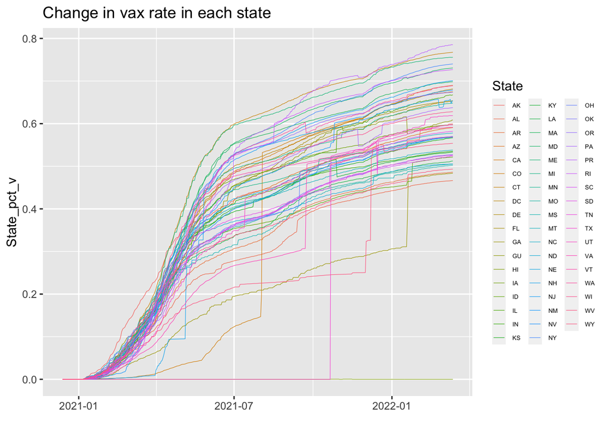

Next we will introduce the mask policy data. As briefly mentioned before, the key variable in this data is binary, i.e., yes or no, and each observation corresponds to the policy status of a county, on a date that is between 04/10/2020 and 08/15/2021: unfortunately, this data was not as up-to-date as the vaccination data, and it only covers a time period that is 16 months long.

The snippet shows the columns that we chose and mutated from the original data. `date`, `County`, `Code` (acronym of the state each observation belongs to) and `Policy` (a factor, “yes”=mask mandate in place for a given state on a specific data, otherwise “no”).

| date | County | Code | Policy |
| --- | --- | --- | --- |
| 2020-04-10 | Autauga County | AL | NA |
| 2020-04-11 | Autauga County | AL | NA |
| 2020-04-12 | Autauga County | AL | NA |

Upon examining the data, we find that there is a big proportion of missingness in the key variable. The visualization below suggests the majority of the missingness in `Policy` predates 2021. This is because mask mandate was not in place in the U.S. prior to that. I.e., the vast majority of those NA’s should be “no”. To obtain a data with a more balanced distribution of “yes” and “no”, we considering removing those entries that predate 2021. Furthermore, most of the missing entries are from a small fraction of the states; if we were to exclude those states, we can bring down the percentage of missing values. Among the remaining entries that still have NA in the key variable, we will fill them with 0.

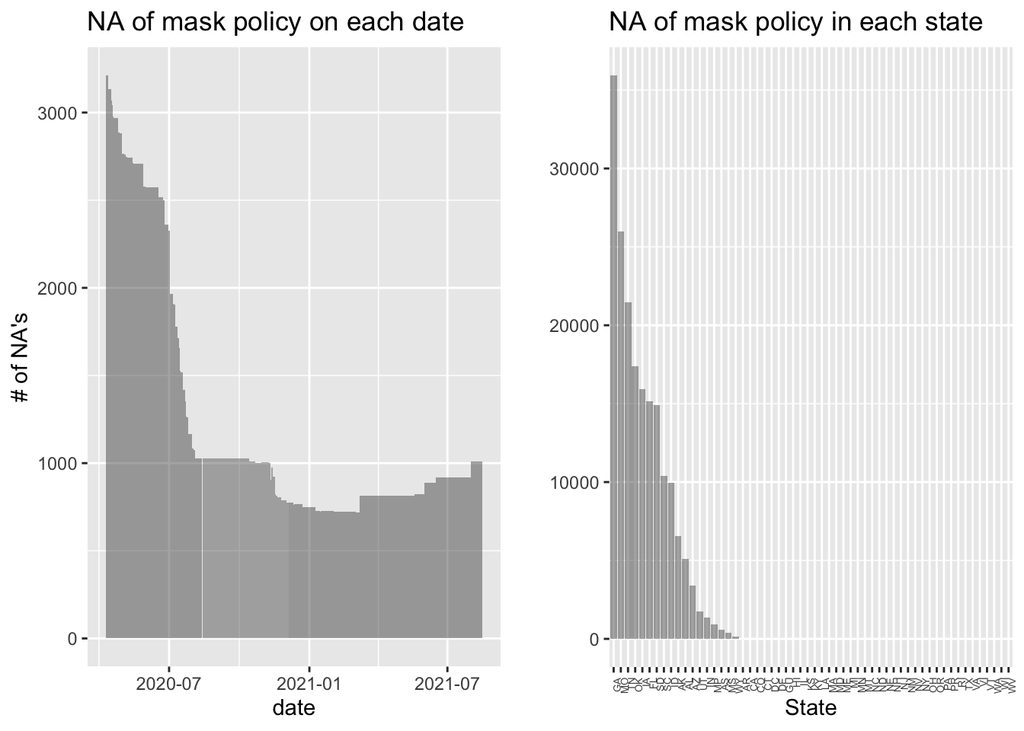

After adjusting the range of mask mandate data, we add a new column, `State_pct_m` to describe the percentage of population that is under mask mandate on a given day within a given state, with the help of a county-level population data. The summary table of this updated data shows that the minimum of percentage of population masked in the time period is 0 (no county of that state had mandates) and the maximum is 1 (all counties had mandates).

Before joining the vaccine data to mask data in order to add population column, we need to concatenate the county and state variables. This is because some counties in different state share the same name. In this process, we also inevitably have to sacrifice some of the observations dated outside the range we specified.

| date.x | Code | state_mask | Policy | State_pop | State_pct_m |
| --- | --- | --- | --- | --- | --- |
| 2020-12-13 | AR | 3017804 | Yes | 3017804 | 1 |
| 2020-12-14 | AR | 3017804 | Yes | 3017804 | 1 |
| 2020-12-15 | AR | 3017804 | Yes | 3017804 | 1 |

For this data that contains 15 variables, some related to infection case and deaths, we will select the following 3: `submission_date` (date of counts), `state`, and `new_death` (number of new deaths). We noticed some observations have negative values in `new_death`, potentially due to entry error or calculation error. Before moving on, we will remove these rows.

Then using `new_death`, we create two additional columns, which are 7-day moving average of new death and 14-day moving average of new death, with `rollmean` from package `zoo`. The rows where NA’s were produced, we fill them with zero. We chose to mutate these columns as candidates for response variable in our model, considering factors like “masks will most likely have a lagged effect on death case since they work by lowering transmission”.

The final U.S. death data is summarized below. We can see that `death_lag_7` is distributed differently from original variable, whose skewness can be seen from its 1st quantile and median. The `death_lag_14` has even smaller maximum compared to 7_day average, due to the extent it further smooths the curve.

|  | submission_date | state | new_death | death_lag_7 | death_lag_14 |
| --- | --- | --- | --- | --- | --- |
|  | Min. :2020-01-22 | Length:46685 | Min. : 0.00 | Min. : 0.000 | Min. : 0.00 |
|  | 1st Qu.:2020-08-04 | Class :character | 1st Qu.: 0.00 | 1st Qu.: 8.571 | 1st Qu.: 11.36 |
|  | Median :2021-02-15 | Mode :character | Median : 4.00 | Median : 15.143 | Median : 17.07 |
|  | Mean :2021-02-15 | NA | Mean : 20.32 | Mean : 20.320 | Mean : 20.32 |
|  | 3rd Qu.:2021-08-30 | NA | 3rd Qu.: 20.00 | 3rd Qu.: 26.000 | 3rd Qu.: 25.64 |
|  | Max. :2022-03-13 | NA | Max. :1178.00 | Max. :195.571 | Max. :122.07 |

By visualizing these two variables by themselves and log-transformed, we can see that both moving averages are highly skewed. Using log-transformation as an initial guess, their distribution were significantly improved. Additionally, 14-day lagged death (log) might be a better candidate since it has more approximately normal distribution.

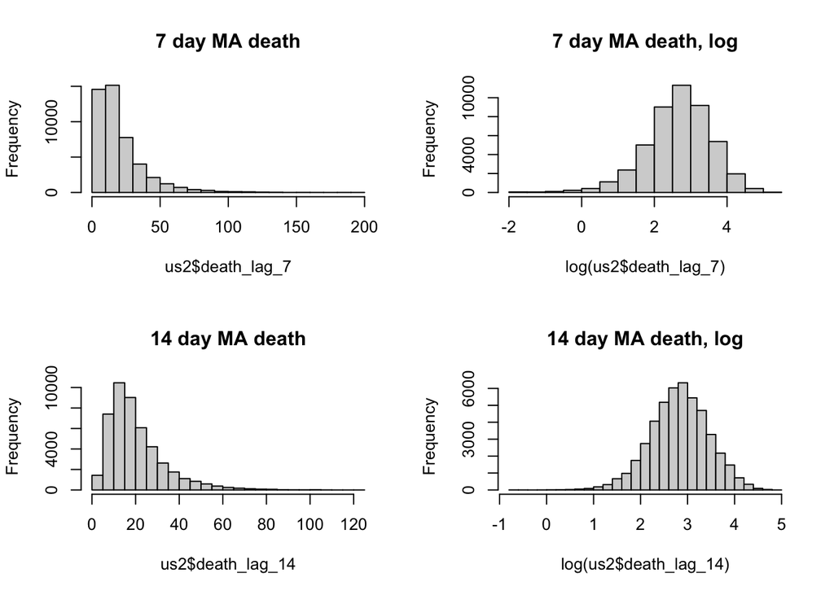

# 4 Inferencial Analysis

After obtaining the final dataset, we begin to fit the model. The model we will use in this project is a multiple regression model, i.e.,

$$Y_i = \beta_0 + \beta_{vax,i} + \beta_{mask,i} + \epsilon_{i}$$

$Y_i$ would be the 7-day moving average of new deaths, $\beta_{vax,i}$ and $\beta_{mask,i}$ are coefficients associated with vaccination rates and percentage of population under mask mandate, respectively. $\epsilon_i$’s are the error term.

| obs | State_pct_v | State_pct_m | death_lag_7 | death_lag_14 |
| --- | --- | --- | --- | --- |
| AR, 2020-12-13 | 0 | 1 | 18.14286 | 19.714286 |
| AR, 2020-12-14 | 0 | 1 | 13.00000 | 14.642857 |
| AR, 2020-12-15 | 0 | 1 | 12.57143 | 8.785714 |

By taking a look at the fitted coefficients of the initial model, we can see that all coefficients are highly significant. However, we are surprised to find that the one associated with mask percentage is positive. That is to say, the more people mask in a state on a given day, the higher 7-day moving average of death become. This is quite surprising and might indicate inaccuracy in the model. This may be indicative of potential problems.

|  | Estimate | Std. Error | t value | Pr(>\|t\|) |
| --- | --- | --- | --- | --- |
| (Intercept) | 21.73742 | 0.4681428 | 46.433301 | 0.0000000 |
| State_pct_v | -12.22146 | 1.0568359 | -11.564196 | 0.0000000 |
| State_pct_m | 1.57671 | 0.4294678 | 3.671311 | 0.0002426 |

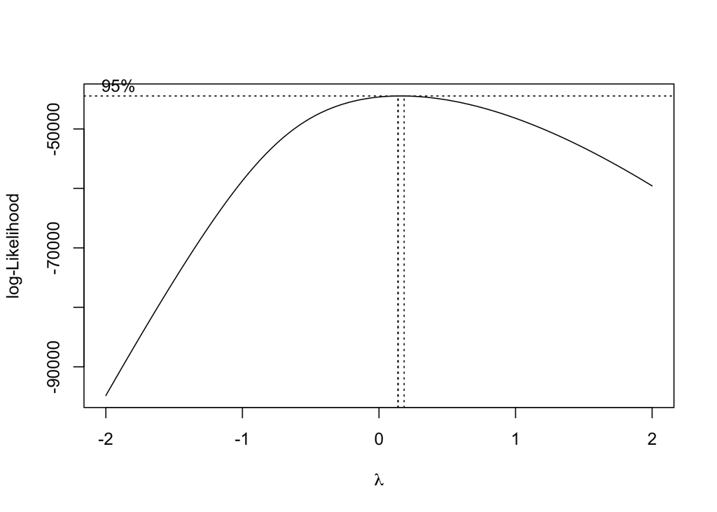

After the transformation, the coefficients changed accordingly. However, the one associated with mask is still positive. We will continue the sensitivity analysis with this observation in mind.

|  | Estimate | Std. Error | t value | Pr(>\|t\|) |
| --- | --- | --- | --- | --- |
| (Intercept) | 2.7155632 | 0.0228822 | 118.675951 | 0e+00 |
| State_pct_v | -0.5940765 | 0.0516567 | -11.500480 | 0e+00 |
| State_pct_m | 0.1096301 | 0.0209918 | 5.222526 | 2e-07 |